# 241212

241212 강의내용

## newaxis는 주로:

- 1차원 배열을 특정 방향(행/열)으로 확장해야 할 때
- 두 배열 간의 모든 조합을 계산해야 할 때
- 행렬 연산에서 차원을 명시적으로 제어해야 할 때 사용됩니다.

```python
import numpy as np
# 1차원 배열
a = np.array([1, 2, 3])
print("원본:", a.shape)
```

```
원본: (3,)
```

```python
b = a[np.newaxis, :]
print(b)
print("행 벡터:", b.shape)
```

```
[[1 2 3]]
행 벡터: (1, 3)
```

```python
c = a[:, np.newaxis]
print(c)
print("열 벡터:", c.shape)
```

```
[[1]
 [2]
 [3]]
열 벡터: (3, 1)
```

```python
print(a*a)
```

```
[1 4 9]
```

```python
print(a*b)
```

```
[[1 4 9]]
```

```python
print(a*c)
```

```
[[1 2 3]
 [2 4 6]
 [3 6 9]]
```

```python
import numpy as np
# 이미지 픽셀, 가중치
pixels = np.array([1, 2, 3])
weights = np.array([0.5, 1.0, 1.5])
print(pixels.shape)
result = pixels * weights
print(result)
```

```
(3,)
[0.5 2.  4.5]
```

```python
pixels_col = pixels[:, np.newaxis]
print(pixels_col)
print(pixels_col.shape)
```

```
[[1]
 [2]
 [3]]
(3, 1)
```

```python
result = pixels_col * weights
print(result)
```

```
[[0.5 1.  1.5]
 [1.  2.  3. ]
 [1.5 3.  4.5]]
```

```python
import numpy as np

# 기본 배열
a = np.array([1, 2, 3])        # shape: (3,)
print(a.shape)
b = np.array([[4], [5], [6]])  # shape: (3,1)
print(b.shape)
c = a + b
print(c.shape)
c
```

```
(3,)
(3, 1)
(3, 3)
```

```
array([[5, 6, 7],
       [6, 7, 8],
       [7, 8, 9]])
```

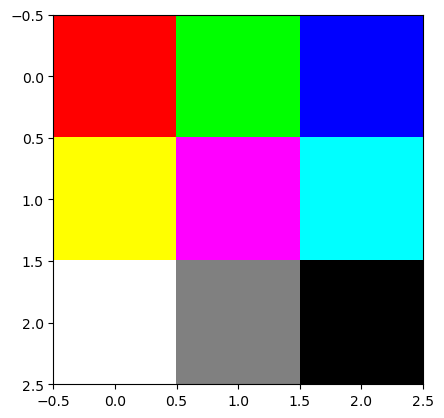

```
Gray Image:
 [[ 85.  85.  85.]
 [170. 170. 170.]
 [255. 128.   0.]]
```

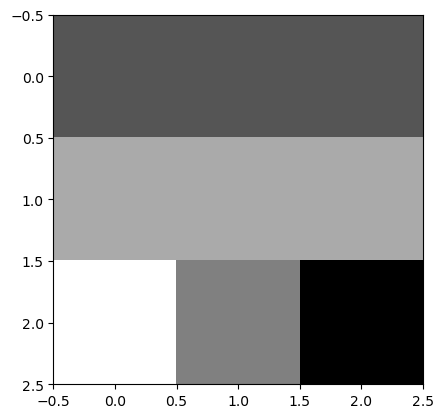

```python
# np.mean

import numpy as np
import matplotlib.pyplot as plt

# 예제 컬러 이미지 (3x3)
color_image = np.array([[[255, 0, 0], [0, 255, 0], [0, 0, 255]],
                        [[255, 255, 0], [255, 0, 255], [0, 255, 255]],
                       [[255, 255, 255], [128, 128, 128], [0, 0, 0]]], dtype=np.uint8)

# 시각화
plt.imshow(color_image, cmap='BrBG')
plt.show()

# 흑백 변환
gray_image = np.mean(color_image, axis=2)
print("Gray Image:\n", gray_image)

# 시각화
plt.imshow(gray_image, cmap='gray')
plt.show()
```

### 슬라이싱

```python
import numpy as np
arr = np.array([10, 11, 12, 13, 14, 15, 16, 17, 18, 19])

print(arr[::2])    # 처음부터 끝까지 2씩 증가
print(arr[::3])    # 처음부터 끝까지 3씩 증가
print(arr[0:7:2])  # 0부터 6까지 2씩 증가
print(arr[5::2])   # 5부터 끝까지 2씩 증가
print(arr[::-1])   # 역순으로 1씩 증가
print(arr[:])      # 전체
```

```
[10 12 14 16 18]
[10 13 16 19]
[10 12 14 16]
[15 17 19]
[19 18 17 16 15 14 13 12 11 10]
[10 11 12 13 14 15 16 17 18 19]
```

### 넘파이 검색

- 배열에서 특정 값을 검색하여 일치하는 데이터의 인덱스를 변환
- 배열에서 원하는 값을 찾으려면 where() 메서드를 사용한다

```python
# np.where(조건, True 값, False 값)

import numpy as np
arr = np.array([1, 2, 3, 4, 5, 4, 4])
print(arr[arr < 4])
x = np.where(arr < 4) # --> 인덱스 정보
print(arr[x])
```

```
[1 2 3]
[1 2 3]
```

```python
# np.where(조건, True 값, False 값)

import numpy as np
arr = np.array([1, 2, 3, 4, 5, 6, 7, 8])
# arr[arr < 4]
# x = np.where(arr % 2 == 0) # --> 인덱스 정보
x = np.where(arr % 2 == 1) # --> 인덱스 정보
print(arr[x])
```

```
[1 3 5 7]
```

```python
import numpy as np

# 성적 배열
scores = np.array([85, 67, 90, 45, 78, 92])
pass_mark = 60

result = np.where(scores >= pass_mark,'합격','불합격')
print(result)
print(scores)
```

```
['합격' '합격' '합격' '불합격' '합격' '합격']
[85 67 90 45 78 92]
```

```python
list(zip(scores,result))
```

```
[(85, '합격'), (67, '합격'), (90, '합격'), (45, '불합격'), (78, '합격'), (92, '합격')]
```

```python
dict(zip(scores,result))
```

```
{85: '합격', 67: '합격', 90: '합격', 45: '불합격', 78: '합격', 92: '합격'}
```

```python
# 옷 추천
import numpy as np
# 기온 배열 (섭씨)
temperatures = np.array([15, 25, 30, 10, 5])
# 10도 미만: 코트, 20도 미만: 가디건, 그외: 반팔 티셔츠
result = np.where(temperatures < 10, '코트', np.where(temperatures <20, '가디건', '반팔 티셔츠'))
print(result)
list(zip(temperatures,result))
```

```
['가디건' '반팔 티셔츠' '반팔 티셔츠' '가디건' '코트']
```

```
[(15, '가디건'), (25, '반팔 티셔츠'), (30, '반팔 티셔츠'), (10, '가디건'), (5, '코트')]
```

```python
## 고객 등급 분류

import numpy as np
# 고객의 구매 금액 배열
purchases = np.array([150, 300, 50, 700, 1200])
# 100 미만: 브론즈, 500 미만: 실버, 그 이상: 골드

result = np.where(purchases < 100, '브론즈', np.where(purchases < 500, '실버', '골드'))
print(result)
list(zip(purchases,result))
```

```
['실버' '실버' '브론즈' '골드' '골드']
```

```
[(150, '실버'), (300, '실버'), (50, '브론즈'), (700, '골드'), (1200, '골드')]
```

```python
import numpy as np
arr = np.array([[1, 2, 3],
               [4, 5, 6],
               [7, 8, 9]])

x = np.where(arr > 5)
print(x)
list(zip(x[0], x[1]))
```

```
(array([1, 2, 2, 2], dtype=int64), array([2, 0, 1, 2], dtype=int64))
```

```
[(1, 2), (2, 0), (2, 1), (2, 2)]
```

```python
arr[x]
```

```
array([6, 7, 8, 9])
```

```python
import numpy as np
arr_3d = np.array([
    [[1, 2, 3, 4],
    [5, 6, 7, 8],
    [9, 10, 11, 12]],

    [[13, 14, 15, 16],
    [17, 18, 19, 20],
    [21, 22, 23, 24]]
])

print(arr.shape)
```

```
(3, 3)
```

```python
result = np.where(arr_3d < 10)
print("결과:", result)
```

```
결과: (array([0, 0, 0, 0, 0, 0, 0, 0, 0], dtype=int64), array([0, 0, 0, 0, 1, 1, 1, 1, 2], dtype=int64), array([0, 1, 2, 3, 0, 1, 2, 3, 0], dtype=int64))
```

```python
print(list(zip(*result)))
```

```
[(0, 0, 0), (0, 0, 1), (0, 0, 2), (0, 0, 3), (0, 1, 0), (0, 1, 1), (0, 1, 2), (0, 1, 3), (0, 2, 0)]
```

```python
print(list(zip(result[0], result[1], result[2])))
```

```
[(0, 0, 0), (0, 0, 1), (0, 0, 2), (0, 0, 3), (0, 1, 0), (0, 1, 1), (0, 1, 2), (0, 1, 3), (0, 2, 0)]
```

```python
for d,r,c in zip(*result):
    print(f"위치 ({d},{r},{c})의 값: {arr_3d[d,r,c]}")
```

```
위치 (0,0,0)의 값: 1
위치 (0,0,1)의 값: 2
위치 (0,0,2)의 값: 3
위치 (0,0,3)의 값: 4
위치 (0,1,0)의 값: 5
위치 (0,1,1)의 값: 6
위치 (0,1,2)의 값: 7
위치 (0,1,3)의 값: 8
위치 (0,2,0)의 값: 9
```

```python
y = np.where(arr_3d < 15 , True, False)
print(y)
```

```
[[[ True  True  True  True]
  [ True  True  True  True]
  [ True  True  True  True]]

 [[ True  True False False]
  [False False False False]
  [False False False False]]]
```

## argmax(), argmin() 메서드

- 배열에서 가장 큰 값 또는 가장 작은 값의 위치(인덱스)를 찾아준다.
  - argmax(): 가장 큰 값의 위치(인덱스) 찾기
  - argmin(): 가장 작은 값의 위치(인덱스) 찾기
- 기본적으로 배열을 평탄화(flatten)하여 인덱스를 변환

```python
import numpy as np
arr = np.array([[11, 12, 13, 14, 15],
               [21, 22, 23, 24, 25]])

print(arr.max())
print(arr.min())

print(np.argmax(arr))
print(np.argmax(arr, axis = 0)) # 행 ↓
print(np.argmax(arr, axis = 1)) # 열 →
print('-'*20)
print(np.argmin(arr))
print(np.argmin(arr, axis = 0)) # 행
print(np.argmin(arr, axis = 1)) # 열
```

```
25
11
9
[1 1 1 1 1]
[4 4]
--------------------
0
[0 0 0 0 0]
[0 0]
```

```python
##
import numpy as np
scores = np.array([88, 92, 79, 95, 85])
x = np.argmax(scores)
y = np.argmin(scores)
print(x, y)

x1 = scores.argmax()
y1 = scores.argmin()
print(x1, y1)
```

```
3 2
3 2
```

```python
import numpy as np

# 학생 성적: 행은 학생, 열은 과목
scores = np.array([[88, 92, 79],
                  [85, 90, 95],
                  [78, 88, 80]])

# 각 과목별 최고 성적 인덱스
max_sub = np.argmax(scores, axis = 0) # 행 ↓  [0 0 1] 이거의 인덱스 0,1,2-> 열을 표시함 값은 행을 표시함 따라서 axis=0 은 행으로 불림
print(f"과목별 최고 성적 index: {max_sub}")

# 각 과목별 최저 성적 인덱스
min_sub = np.argmin(scores, axis = 0) # 행 ↓
print(f"과목별 최저 성적 index: {min_sub}")

scores.shape[1]

# 최고 성적의 값 추출
max_val = scores[max_sub, np.arange(scores.shape[1])] # np.arange(scores.shape[1]) -> [0, 1, 2]
# 최저 성적의 값 추출
min_val = scores[min_sub, np.arange(scores.shape[1])]

print("각 과목 최고 성적:", max_val) # [0 0 1] 이거의 인덱스 0,1,2-> 열을 표시함 값은 행을 표시함
print("각 과목 최저 성적:", min_val)

print(list(zip(max_val, max_sub)))
print(list(zip(min_val, min_sub)))
```

```
과목별 최고 성적 index: [0 0 1]
과목별 최저 성적 index: [2 2 0]
각 과목 최고 성적: [88 92 95]
각 과목 최저 성적: [78 88 79]
[(88, 0), (92, 0), (95, 1)]
[(78, 2), (88, 2), (79, 0)]
```

```python
scores = np.array([[88, 92, 79],
                  [85, 90, 95]])
scores.shape[0]
```

```
2
```

```python
# 도시별 온도 기록 (행: 도시, 열: 요일)
temperatures = np.array([[22, 25, 20, 19, 23, 24, 21],
                        [30, 32, 31, 29, 28, 27, 26],
                        [15, 14, 16, 17, 18, 19, 20]])

# 도시별 최고 기온 인덱스
max_temp = np.argmax(temperatures, axis = 1)
print('도시별 최고 기온 인덱스', max_temp)

# 도시별 최저 기온 인덱스
min_temp = np.argmin(temperatures, axis = 1)
print('도시별 최저 기온 인덱스', min_temp)

# 최고 기온의 값 추출
max_val = temperatures[np.arange(temperatures.shape[0]), max_temp] # np.arange(temperatures.shape[0]) -> [0, 1, 2]
# 최저 기온의 값 추출
min_val = temperatures[np.arange(temperatures.shape[0]), min_temp]

print("각 도시별 최고 기온:", max_val)
print(list(zip(max_val, np.arange(temperatures.shape[0]),max_temp)))
print("각 도시별 최저 기온:", min_val)
print(list(zip(min_val, np.arange(temperatures.shape[0]),min_temp)))
```

```
도시별 최고 기온 인덱스 [1 1 6]
도시별 최저 기온 인덱스 [3 6 1]
각 도시별 최고 기온: [25 32 20]
[(25, 0, 1), (32, 1, 1), (20, 2, 6)]
각 도시별 최저 기온: [19 26 14]
[(19, 0, 3), (26, 1, 6), (14, 2, 1)]
```

# 넘파이 정렬

- 정렬은 배열 요소를 순서대로 배열하는 것을 말한다.
- 정련된 순서는 숫자 또는 문자와 같은 요소를 오름차순 또는 내림차순 순서로 배열하는 것을 말한다.
- 넘파이 배열 객체에는 배열을 정렬하는 sort()라는 메서드가 있다.

## np.sort, np.argsort() 메서드

- sort() 메서드 및 np.argsort() 메서드는 배열 데이터를 정렬하는데 매우 유용
  - np.sort(arr): 원본 데이터는 그대로 두고 임시로 정렬된 배열을 보여준다.
  - 벼열명.sort(): 배열에 저장된 데이터를 정렬한 다음 정렬된 데이터를 저장
  - np.argsort(): 데이터가 정렬되었을 때의 각 데이터 위치(인덱스)를 반환

```python
import numpy as np
arr = np.array([2, 1, 5, 3, 7, 4, 6, 8])

print("arr:",arr)
print("np.sort:",np.sort(arr)) # 실제로 원본데이터가 바뀌는건 아님
arr2 = np.sort(arr)
print("arr:",arr)
print("arr2:",arr2)
```

```
arr: [2 1 5 3 7 4 6 8]
np.sort: [1 2 3 4 5 6 7 8]
arr: [2 1 5 3 7 4 6 8]
arr2: [1 2 3 4 5 6 7 8]
```

```python
print("arr:",arr)
print("arr.sort:" , arr.sort()) # 원본데이터가 바뀐다.
print("arr:",arr)
```

[output not shown]

```python
print('원본=',arr)
print('정렬=',np.sort(arr))
print('위치=',np.argsort(arr)) # 정렬하기 전에 원본에서의 위치값
print('원본=',arr)
```

[output not shown]

```python
import numpy as np

# 학생 이름과 성적
students  = np.array(['Alice', 'Bob', 'Charlie', 'David', 'Eva'])
scores = np.array([88, 92, 75, 95, 85])

# 성적 정렬 및 원래 인덱스 찾기
sorted_indices = np.argsort(scores)  # 정렬하기 전 성적에서의 위치값을 저장
print(sorted_indices)
sorted_scores = np.sort(scores) # 성적 정렬
print(sorted_scores)
sorted_students = students[sorted_indices] # 위치값 저장한걸 활용하여 학생 명단 정렬
print(sorted_students)

# 결과 출력
print("학생 성적 정렬 결과:")
for i in range(len(sorted_scores)):
    print(f"{sorted_students[i]}: {sorted_scores[i]}점 (원래 인덱스 {sorted_indices[i]})")
```

```
[2 4 0 1 3]
[75 85 88 92 95]
['Charlie' 'Eva' 'Alice' 'Bob' 'David']
학생 성적 정렬 결과:
Charlie: 75점 (원래 인덱스 2)
Eva: 85점 (원래 인덱스 4)
Alice: 88점 (원래 인덱스 0)
Bob: 92점 (원래 인덱스 1)
David: 95점 (원래 인덱스 3)
```

## 2차원 배열 정렬

```python
import numpy as np
arr = np.array([[3, 2, 4],
                [5, 0, 1]])

print(np.sort(arr)) # axis=1 (생략시 기본값)
print(np.sort(arr, axis=1)) # axis=1 기본값 # 열 →
# print(arr)
print(np.sort(arr, axis=0))# 행 ↓
```

```
[[2 3 4]
 [0 1 5]]
[[2 3 4]
 [0 1 5]]
[[3 0 1]
 [5 2 4]]
```

```python
import numpy as np

# 학생 성적: 행은 학생, 열은 과목
scores = np.array([[88, 92, 75],  # 학생 1
                  [85, 90, 95],   # 학생 2
                  [78, 88, 80]])  # 학생 3

# 각 과목별 성적 정렬
sorted_scores = np.sort(scores, axis=0)  # 세로축
print("각 과목별 정렬된 성적:")
print(sorted_scores)
```

```
각 과목별 정렬된 성적:
[[78 88 75]
 [85 90 80]
 [88 92 95]]
```

## 넘파이 병합

- 배열 병합은 두 개 이상의 배열의 값을 하나의 배열로 합치는 것
- 넘파이는 병합하려는 배열의 순서를 축과 함께 concatenate() 메서드에 전달한다. 축을 명확하게 입력하지 않으면 0으로 간주

```python
import numpy as np
arr1 = np.array([1, 2, 3])
arr2 = np.array([4, 5, 6])

#[1, 2, 3]    +    [4, 5, 6]

arr = np.concatenate((arr1, arr2)) # 튜플 또는 리스트로 인자를 전달
# arr = np.concatenate((arr1, arr2), axis=0)
print(arr)

# arr3 = np.concatenate((arr1, arr2),axis=1)  # 1차원에서는 X
# print(arr3)
```

```
[1 2 3 4 5 6]
```

```python
## 2차원 배열 병합
import numpy as np

arr1 = np.array([[1, 2], [3, 4]])
arr2 = np.array([[5, 6], [7, 8]])

'''
[1, 2]   1    [5, 6]
[3, 4]   →    [7, 8]

 0 ↓

[5, 6]
[7, 8]
'''

arr = np.concatenate((arr1, arr2), axis = 1)     # 가로축
print(arr)
print(arr.shape)

print("-"*20)

arr1 = np.concatenate((arr1, arr2), axis = 0)    # 세로축
print(arr1)
print(arr1.shape)
```

```
[[1 2 5 6]
 [3 4 7 8]]
(2, 4)
--------------------
[[1 2]
 [3 4]
 [5 6]
 [7 8]]
(4, 2)
```

```python
import numpy as np

# 상점 1의 제품 가격
store1_prices = np.array([[25000, 27000],  # 제품 1
                         [15000, 16000]])  # 제품 2

# 상점 2의 제품 가격
store2_prices = np.array([[24000, 26000],  # 제품 1
                         [15500, 16500]])  # 제품 2

# 가격 정보 병합: 제품별로 가격을 수직으로 병합
combined_prices = np.concatenate((store1_prices, store2_prices), axis=0)

print("병합된 가격 정보:\n",combined_prices)
```

```
병합된 가격 정보:
 [[25000 27000]
 [15000 16000]
 [24000 26000]
 [15500 16500]]
```

```python
import numpy as np

# 과목별 성적
math_scores = np.array([[85, 90],  # 학생1
                       [78, 82]])  # 학생2

english_scores = np.array([[88, 92],  # 학생1
                          [80, 75]])  # 학생2

# 성적 병합: 학생별로 성적을 수평으로 병합
combined_scores = np.concatenate((math_scores, english_scores), axis = 1)

print("병합된 성적:\n",combined_scores)
```

```
병합된 성적:
 [[85 90 88 92]
 [78 82 80 75]]
```

## 넘파이 산술연산

- 산술 연산자 +, -, x, / 를 사용하여 넘파이 배열들 간의 값을 계산

```python
## 더하기
import numpy as np
arr1 = np.array([21, 22, 23, 24, 25])
arr2 = np.array([11, 12, 13, 14, 15])

newarr = arr1 + arr2
print(newarr)

newarr2 = np.add(arr1, arr2)  # 프로그램 작업할때는 이게 안전함
print(newarr2)
```

```
[32 34 36 38 40]
[32 34 36 38 40]
```

```python
## 빼기
newarr = arr1 - arr2
print(newarr)

newarr2 = np.subtract(arr1, arr2)  # 프로그램 작업할때는 이게 안전함
print(newarr2)
```

```
[10 10 10 10 10]
[10 10 10 10 10]
```

```python
## 곱하기
newarr = arr1 * arr2
print(newarr)

newarr2 = np.multiply(arr1, arr2)  # 프로그램 작업할때는 이게 안전함
print(newarr2)
```

```
[231 264 299 336 375]
[231 264 299 336 375]
```

```python
## 나누기
import numpy as np
arr1 = np.array([20, 21, 24, 30, 35])
arr2 = np.array([4, 3, 3, 5, 7])
newarr = arr1 / arr2
print(newarr)

newarr2 = np.divide(arr1, arr2)  # 프로그램 작업할때는 이게 안전함
print(newarr2)
```

```
[5. 7. 8. 6. 5.]
[5. 7. 8. 6. 5.]
```

```python
## 거듭제곱
import numpy as np
arr1 = np.array([1, 2, 3, 4, 5])
arr2 = np.array([1, 2, 3, 4, 5])
newarr = arr1 ** arr2
print(newarr)

newarr2 = np.power(arr1, arr2)  # 몫과 나머지가 개별적인 배열로 튜플로 변환
print(newarr2)
```

```
[   1    4   27  256 3125]
[   1    4   27  256 3125]
```

```python
## 나누기 후 몫과 나머지
import numpy as np
arr1 = np.array([11, 21, 31, 41, 51])
arr2 = np.array([2, 3, 4, 5, 6])

newarr2 = np.divmod(arr1, arr2)  # 프로그램 작업할때는 이게 안전함
print(newarr2)
# print(list(zip(newarr2[0],newarr2[1])))
print(list(zip(arr1, arr2, *newarr2)))
```

```
(array([5, 7, 7, 8, 8]), array([1, 0, 3, 1, 3]))
[(11, 2, 5, 1), (21, 3, 7, 0), (31, 4, 7, 3), (41, 5, 8, 1), (51, 6, 8, 3)]
```

```python
## 절대값
import numpy as np
arr = np.array([1, -2, 3, -4, 5])

newarr = np.absolute(arr)
print(newarr)
```

```
[1 2 3 4 5]
```

## 넘파이 기술통계

- 넘파이는 데이터 집합에 대해 간단한 통계를 계산하는 메서드를 제공

```python
import numpy as np
x = np.array([18, 5, 10, 23, 19, -8, 10, 0, 0, 5, 2, 15, 8, 2, 5, 4, 15, -1, 4, -7, -24, 7, 9, -6, 23, -13])

print(np.sort(x))
print(len(x))                   # 데이터 개수
print(sum(x))                   # 데이터 합계
print(np.mean(x))               # 평균
print(np.var(x))                # 분산 (데이터의 흩어짐 정도를 나타내며, 평균으로부터의 거리의 제곱을 평균한 값)
print(np.std(x))                # 표준편차 (분산의 제곱근으로, 원래 단위로 데이터의 변동성을 나타냄)
print(np.max(x))                # 최대값
print(np.min(x))                # 최소값
print(np.median(x))             # 중앙값 (데이터셋의 갯수를 기준으로 중앙에 위치한 값)
print(np.percentile(x, 25))     # 1사분위수
print(np.percentile(x, 50))     # 2사분위수
print(np.percentile(x, 75))     # 3사분위수
print(np.percentile(x, 100))    # 4가분위수
```

```
[-24 -13  -8  -7  -6  -1   0   0   2   2   4   4   5   5   5   7   8   9
  10  10  15  15  18  19  23  23]
26
125
4.8076923076923075
115.23224852071006
10.734628476137871
23
-24
5.0
0.0
5.0
10.0
23.0
```

```python
import numpy as np

# 학생 성적
x = np.array([88, 92, 75, 95, 85, 70, 90])

print("성적 정렬:",np.sort(x))
print("데이터 개수:",len(x))                # 데이터 개수
print("성적 합계:",sum(x))                  # 데이터 합계
print("평균 성적:",np.mean(x))              # 평균
print("분산:",np.var(x))                    # 분산 (데이터의 흩어짐 정도를 나타내며, 평균으로부터의 거리의 제곱을 평균한 값)
print("표준편차:",np.std(x))                # 표준편차 (분산의 제곱근으로, 원래 단위로 데이터의 변동성을 나타냄)
print("최고 성적:",np.max(x))               # 최대값
print("최소 성적:",np.min(x))               # 최소값
print("성적 중앙값:",np.median(x))          # 중앙값 (데이터셋의 갯수를 기준으로 중앙에 위치한 값)
print("1사분위수:",np.percentile(x, 25))    # 1사분위수
print("2사분위수:",np.percentile(x, 50))    # 2사분위수
print("3사분위수:",np.percentile(x, 75))    # 3사분위수
print("4사분위수:",np.percentile(x, 100))   # 4가분위수
```

```
성적 정렬: [70 75 85 88 90 92 95]
데이터 개수: 7
성적 합계: 595
평균 성적: 85.0
분산: 72.57142857142857
표준편차: 8.518886580500327
최고 성적: 95
최소 성적: 70
성적 중앙값: 88.0
1사분위수: 80.0
2사분위수: 88.0
3사분위수: 91.0
4사분위수: 95.0
```

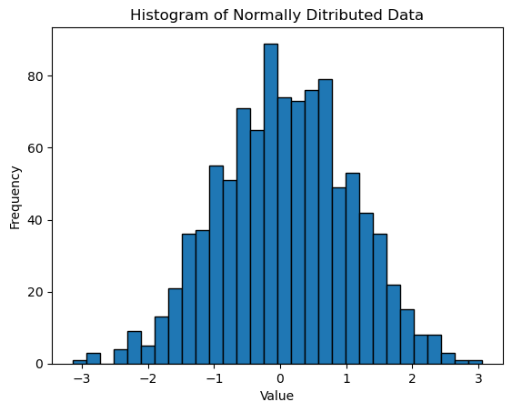

```python
import numpy as np
import matplotlib.pyplot as plt

data = np.random.randn(1000)     # 표준 정규 분포(평균 0, 표준편차 1) 난수
# print(data)
plt.hist(data, bins=30, edgecolor='k')
plt.xlabel('Value')
plt.ylabel('Frequency')
plt.title('Histogram of Normally Ditributed Data')
plt.show()
```

```python
!pip list
```

[output not shown]

[output cut: 331 more lines]

[output not shown]

```python
!pip install wordcloud
```

```
Downloading wordcloud-1.9.4-cp312-cp312-win_amd64.whl (301 kB)
```

```
{'같았다.': 1, '것': 1, '공기를': 1, '구경했다.': 1, '국물의': 1, '기분을': 1, '기분이': 3, '깊었다.': 1, '깔끔하고': 1, '꽃들을': 1, '끝날': 1, '날씨라서': 1, '날씨에': 1, '닿아': 1, '돌아와': 1, '된장찌개': 1, '된장찌개를': 1, '들어왔다.': 1, '따뜻한': 1, '때까지': 1, '마시며': 1, '마음도': 1, '만들어': 1, '맑아지는': 1, '맑았다.': 1, '맑은': 10, '맛이': 1, '먹었다.': 1, '바람이': 1, …
```

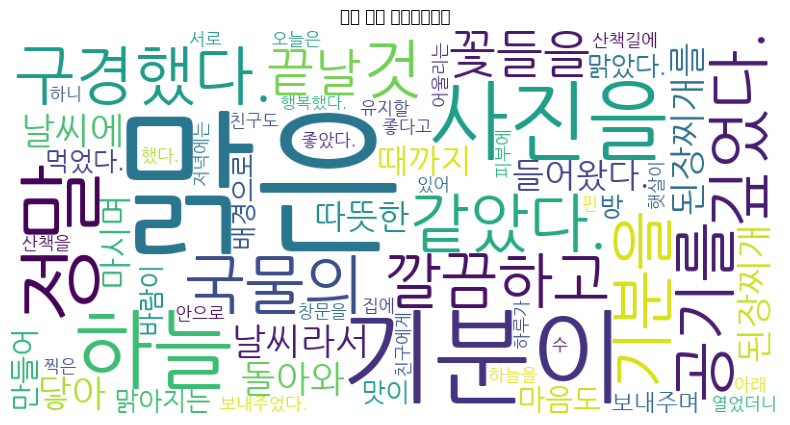

```python
# wordcloud
import numpy as np
import matplotlib.pyplot as plt
from wordcloud import WordCloud

## 한글 안될 때 한글처리
# plt.rc('font', family='Malgun Gothic')
# plt.rcParams['axes.unicode_minus'] = False


text = """오늘은 정말 맑은 날씨라서 기분이 맑았다.
맑은 하늘 아래 산책을 하니 마음도 맑아지는 것 같았다.
맑은 날씨에 어울리는 따뜻한 햇살이 피부에 닿아 기분이 좋았다.
맑은 공기를 마시며 산책길에 핀 꽃들을 구경했다.
집에 돌아와 창문을 열었더니 맑은 바람이 방 안으로 들어왔다.
맑은 하늘을 배경으로 찍은 사진을 친구에게 보내주었다.
친구도 맑은 하늘 사진을 보내주며 서로 기분이 좋다고 했다.
저녁에는 맑은 국물의 된장찌개를 만들어 먹었다.
맑은 된장찌개 맛이 정말 깔끔하고 깊었다.
하루가 끝날 때까지 맑은 기분을 유지할 수 있어 행복했다."""
tokens = text.split()
# print(tokens)

unique_words, counts = np.unique(tokens, return_counts=True)
# print("-"*50)
# print(unique_words) # 중복되는 데이터는 삭제하고 정렬시킴
# print("-"*50)
# print(counts) # 데이터 중복 횟수 표시
freq = dict(zip(unique_words, counts))
print(freq)

wordcloud = WordCloud(width=800, height=400,
                     background_color='white',
                      font_path = r'C:\Users\sejoing\Downloads\NanumGothic.ttf',
                     ).generate_from_frequencies(freq)

plt.figure(figsize=(10, 5))
plt.imshow(wordcloud)
plt.axis('off')
plt.title('단어 빈도 워드클라우드')
plt.show()
```

```python
!pip list
```

[output not shown]

[output cut: 333 more lines]

[output not shown]

```python
!pip install konlpy
```

```python
!pip install JPype1
```

```
['오늘', '정말', '정말 맑은', '정말 맑은 날씨', '기분', '맑은', '맑은 하늘', '맑은 하늘 아래', '맑은 하늘 아래 산책', '하니', '하니 마음', '맑아지는 것', '맑은 날씨', '따뜻한 햇살', '피부', '맑은 공기', '산책길', '핀 꽃들', '구경', '창문', '맑은 바람', '배경', '사진', '친구', '맑은 하늘 사진', '서로', '서로 기분', '저녁', '맑은 국물', '맑은 국물의 된장찌개', '맑은 된장찌개', '맑은 된장찌개 맛', '하루', '맑은 기분', '유지', '유지…
{'공기': 1, '구경': 1, '국물': 1, '기분': 1, '꽃들': 1, '날씨': 1, '된장찌개': 1, '따뜻한 햇살': 1, '마음': 1, '맑아지는 것': 1, '맑은': 1, '맑은 공기': 1, '맑은 국물': 1, '맑은 국물의 된장찌개': 1, '맑은 기분': 1, '맑은 날씨': 1, '맑은 된장찌개': 1, '맑은 된장찌개 맛': 1, '맑은 바람': 1, '맑은 하늘': 1, '맑은 하늘 사진': 1, '맑은 하늘 아래': 1, '맑은 하늘 아래 산책': 1, '바람': 1, '배경': 1, '사진'…
```

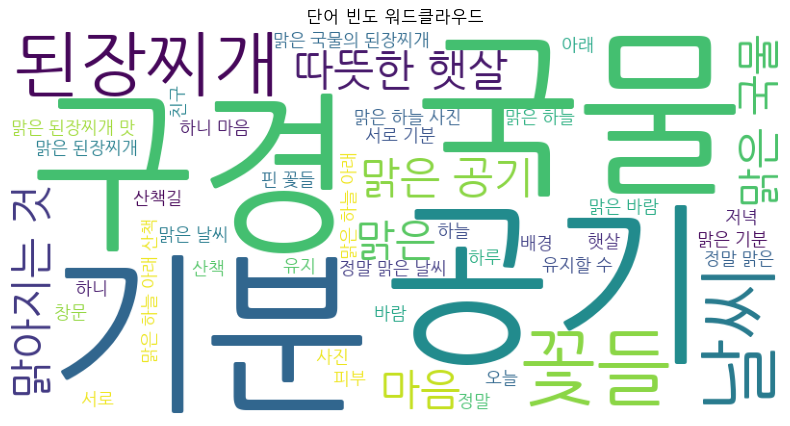

```python
# wordcloud
import numpy as np
import matplotlib.pyplot as plt
from wordcloud import WordCloud
from konlpy.tag import Okt  # 한국어 형태소 분석기

# 한글처리
plt.rc('font', family='Malgun Gothic')
plt.rcParams['axes.unicode_minus'] = False


text = """오늘은 정말 맑은 날씨라서 기분이 맑았다.
맑은 하늘 아래 산책을 하니 마음도 맑아지는 것 같았다.
맑은 날씨에 어울리는 따뜻한 햇살이 피부에 닿아 기분이 좋았다.
맑은 공기를 마시며 산책길에 핀 꽃들을 구경했다.
집에 돌아와 창문을 열었더니 맑은 바람이 방 안으로 들어왔다.
맑은 하늘을 배경으로 찍은 사진을 친구에게 보내주었다.
친구도 맑은 하늘 사진을 보내주며 서로 기분이 좋다고 했다.
저녁에는 맑은 국물의 된장찌개를 만들어 먹었다.
맑은 된장찌개 맛이 정말 깔끔하고 깊었다.
하루가 끝날 때까지 맑은 기분을 유지할 수 있어 행복했다."""


okt = Okt()
# words = okt.nouns(text)
words = okt.phrases(text)
print(words)

# 2글자 이상인 단어만 필터링
# filtered_words = [word for word in words if len(word) > 1]


# ---------------넘파이 사용 안할시-------------------
# freq = {}
# for word in words:
#     if len(word) > 1:
#         freq[word] = freq.get(word, 0) + 1
# ----------------------------------------------------


# -----------------넘파이 사용시----------------------------
unique_words, counts = np.unique(words, return_counts=True)
freq = dict(zip(unique_words, counts))
# ----------------------------------------------------------


print(freq)


wordcloud = WordCloud(width=800, height=400,
                     background_color='white',
                      font_path = r'C:\Users\sejoing\Downloads\NanumGothic.ttf',
                     ).generate_from_frequencies(freq)

plt.figure(figsize=(10, 5))
plt.imshow(wordcloud)
plt.axis('off')
plt.title('단어 빈도 워드클라우드')
plt.show()
```